# Capstone Project: Bellabeat

Ashir Dill

08/07/2024

Introduction

Bellabeat is a small tech company who is hoping to become more profitable within the next coming year. They have asked us to take data from a more popular and widely known brand, FitBit, and analyze their data in hopes to enhance their own product line and become more marketable.

1. ASK.

As a business task, Bellabeat has asked their market analysis team to perform and open source analysis on other similar smart devices in order to gain insights into their strategies, products, and success in hopes that Bellabeat will be able to be more profitable in the future.

KEY STAKEHOLDERS INCLUDE:

Urska Srsen - Cofounder of Bellabeat Sando Mur - Also cofounder as well as a mathmatician Bellabeat Market Research and Analytics Team

2. PREPARE

I will be analyzing this data for integrity and reliability. This is a smaller sample size of data.

This data includes 18 csv files. I will be focusing more on the DailyActivity_merged, dailySteps_merged, SleepDay_merged, weightLoginfo_merged. I will clean and remove files which are not useful in my analysis.

INSTALLING LIBRARIES and PACKAGES

The following packages were installed and libraries loaded:

install.packages(“ggplot”) * (“dplyr”) * (“tidyr”) * (“tibble”) * (“readr”) * (“stringr”) * (“forcats”) * (“purr”)

Here is an example code chunk I used for all of the packages/libraries mentioned above.

```r
install.packages("ggplot2")
install.packages("dplyr")
install.packages("tidy")
install.packages("tibble")
install.packages("readr")
install.packages("stringr")
install.packages("forcats")
install.packages("purrr")
library(ggplot2)
library("ggplot2")
library("dplyr")
library("tidyr")
library("tibble")
library("readr")
library("stringr")
library("forcats")
library("purrr")
```

```r
setwd("/cloud/project")
```

```r
DailyActivity <- read.csv("dailyActivity_merged.csv")
SleepDay <- read.csv("/cloud/project/sleepDay_merged.csv")
DailySteps <- read.csv("/cloud/project/dailySteps_merged.csv")
DailyCalories <- read.csv("/cloud/project/dailyCalories_merged.csv")
DailyIntensities <- read.csv("/cloud/project/dailyIntensities_merged.csv")
Weight <- read.csv("/cloud/project/weightLogInfo_merged.csv")
```

Once the data was loaded, I performed the following quick functions to review the data quickly before analyzing it:

```r
head(DailyActivity)
```

```
##           Id ActivityDate TotalSteps TotalDistance TrackerDistance
## 1 1503960366    4/12/2016      13162          8.50            8.50
## 2 1503960366    4/13/2016      10735          6.97            6.97
## 3 1503960366    4/14/2016      10460          6.74            6.74
## 4 1503960366    4/15/2016       9762          6.28            6.28
## 5 1503960366    4/16/2016      12669          8.16            8.16
## 6 1503960366    4/17/2016       9705          6.48            6.48
##   LoggedActivitiesDistance VeryActiveDistance ModeratelyActiveDistance
## 1                        0               1.88                     0.55
## 2                        0               1.57                     0.69
## 3                        0               2.44                     0.40
## 4                        0               2.14                     1.26
## 5                        0               2.71                     0.41
## 6                        0               3.19                     0.78
##   LightActiveDistance SedentaryActiveDistance VeryActiveMinutes
## 1                6.06                       0                25
## 2                4.71                       0                21
## 3                3.91                       0                30
## 4                2.83                       0                29
## 5                5.04                       0                36
## 6                2.51                       0                38
##   FairlyActiveMinutes LightlyActiveMinutes SedentaryMinutes Calories
## 1                  13                  328              728     1985
## 2                  19                  217              776     1797
## 3                  11                  181             1218     1776
## 4                  34                  209              726     1745
## 5                  10                  221              773     1863
## 6                  20                  164              539     1728
```

The str() function allowed me to preview the structure of my data, i.e. dataframes, etc.

```r
str(DailyActivity)
```

```
## 'data.frame':    940 obs. of  15 variables:
##  $ Id                      : num  1.5e+09 1.5e+09 1.5e+09 1.5e+09 1.5e+09 ...
##  $ ActivityDate            : chr  "4/12/2016" "4/13/2016" "4/14/2016" "4/15/2016" ...
##  $ TotalSteps              : int  13162 10735 10460 9762 12669 9705 13019 15506 10544 9819 ...
##  $ TotalDistance           : num  8.5 6.97 6.74 6.28 8.16 ...
##  $ TrackerDistance         : num  8.5 6.97 6.74 6.28 8.16 ...
##  $ LoggedActivitiesDistance: num  0 0 0 0 0 0 0 0 0 0 ...
##  $ VeryActiveDistance      : num  1.88 1.57 2.44 2.14 2.71 ...
##  $ ModeratelyActiveDistance: num  0.55 0.69 0.4 1.26 0.41 ...
##  $ LightActiveDistance     : num  6.06 4.71 3.91 2.83 5.04 ...
##  $ SedentaryActiveDistance : num  0 0 0 0 0 0 0 0 0 0 ...
##  $ VeryActiveMinutes       : int  25 21 30 29 36 38 42 50 28 19 ...
##  $ FairlyActiveMinutes     : int  13 19 11 34 10 20 16 31 12 8 ...
##  $ LightlyActiveMinutes    : int  328 217 181 209 221 164 233 264 205 211 ...
##  $ SedentaryMinutes        : int  728 776 1218 726 773 539 1149 775 818 838 ...
##  $ Calories                : int  1985 1797 1776 1745 1863 1728 1921 2035 1786 1775 ...
```

3. PROCESS

In this phase of the analysis, now that I have successfully installed my datasets, I will perform a thorough analysis of any abnormalities within the data.

I started by checking for any missing values using the following code chunk:

```r
sum(is.na(DailyActivity))
```

```
## [1] 0
```

```r
sum(is.na(DailyCalories))
```

```
## [1] 0
```

```r
sum(is.na(DailyIntensities))
```

```
## [1] 0
```

```r
sum(is.na(DailySteps))
```

```
## [1] 0
```

```r
sum(is.na(SleepDay))
```

```
## [1] 0
```

```r
data_unique <- unique(DailyActivity)
```

In the next step of cleaning the data, I checked for any formatting errors and converted any date column which was not characterized as such, using the following code:

```r
DailyActivity$ActivityDate <- as.Date(DailyActivity$ActivityDate, format ="%m,%d,%Y")
DailyCalories$ActivityDay <- as.Date(DailyCalories$ActivityDay, format = "%m,%d,%Y")
DailyIntensities$ActivityDay <- as.Date(DailyIntensities$ActivityDay, format = "%m,%d,%Y")
DailySteps$ActivityDay <- as.Date(DailySteps$ActivityDay, format = "%m,%d,%Y")
SleepDay$SleepDay <- as.Date(SleepDay$SleepDay, format = "%m,%d,%Y")
```

Next, I used the following code chunk to quickly summize how many participants we have in each study as I will be removing the datasets with less than at least 10 particiapnts.

```r
n_distinct(DailyCalories$Id)
```

```
## [1] 33
```

```r
n_distinct(DailyActivity$Id)
```

```
## [1] 33
```

```r
n_distinct(DailyIntensities$Id)
```

```
## [1] 33
```

```r
n_distinct(DailySteps$Id)
```

```
## [1] 33
```

```r
n_distinct(SleepDay$Id)
```

```
## [1] 24
```

4. ANALYZE

In this step of the analysis phase, I will test my hypothesis using charts and graphs.

There is a positive corelation between calories burnt and the distance covered. Studies have shown that an increase in activity level can improve sleep patterns. Levels of activity vary between different times and days for different people. One thing to note is that people regularly do not reach the recomended 10,000 daily steps by the American Heart Association.

I will start my analysis with plotting a chart showing Total Distance Vs. Total Steps is positively correlated by using the following code chunk:

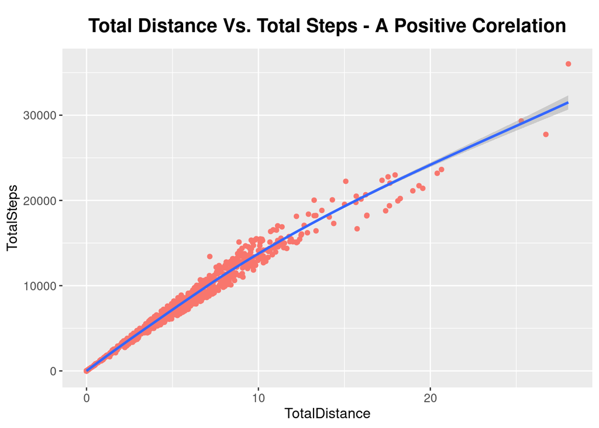

```r
ggplot(data = DailyActivity, theme = theme_minimal())+
  geom_point(mapping = aes(x = TotalDistance, y=TotalSteps, color="green"))+
  geom_smooth(mapping = aes(x=TotalDistance, y=TotalSteps))+
  labs(title = "Total Distance Vs. Total Steps - A Positive Corelation", xlab="Total Distance(km)", ylab="Total Steps")+
  scale_color_discrete(name="Variable", guide = "none")+
  theme(plot.title = element_text(size= 20, hjust = 0.5))+
  theme(plot.title = element_text(face = "bold",
                                  margin = margin(10, 0, 10, 0),
                                  size = 16),
        axis.title = element_text(size = 12),
        axis.text = element_text(size = 10))
```

Next, I will be looking further into the relationship between Total Calories Vs. Total Distance. I will plot a chart showing this using the following code chunk:

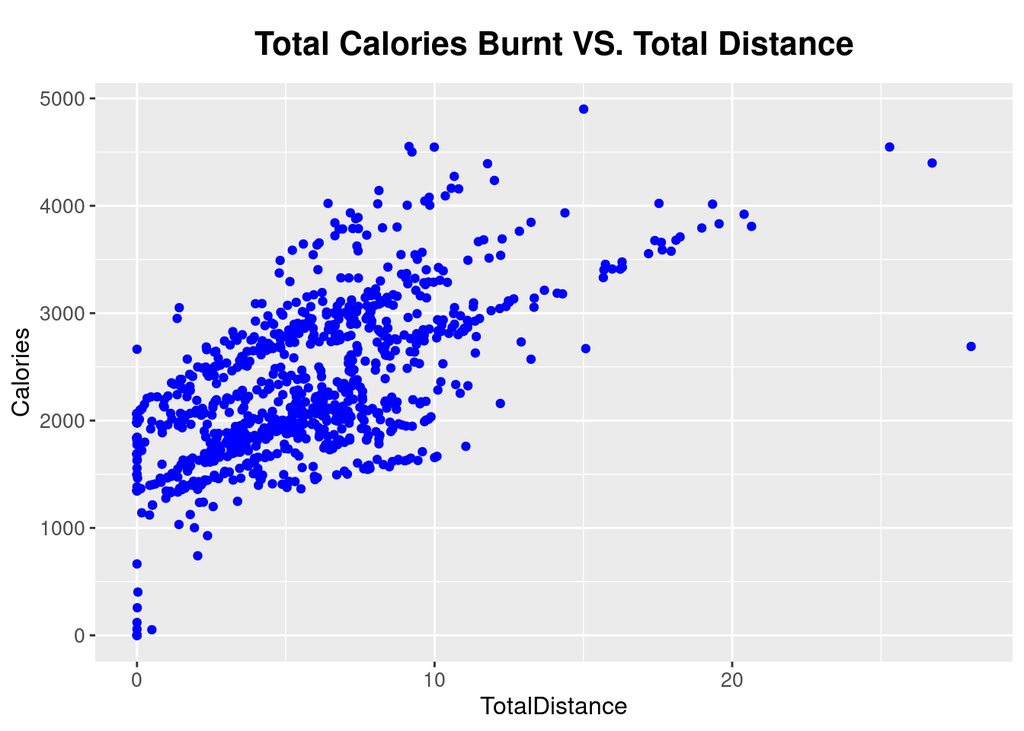

```r
ggplot(data=DailyActivity, theme = theme_minimal())+
  geom_point(mapping = aes(x= TotalDistance, y= Calories), color="blue")+
  geom_smooth(mapping = aes(x = TotalDistance, y= Calories), method = "loess", formula = "y-x")+
  labs(title = "Total Calories Burnt VS. Total Distance", xlab= "Total Distance", ylab="Total Calories")+
  scale_color_discrete(name="Variable", guide = "none")+
  theme(plot.title = element_text(size= 20, hjust = 0.5))+
  theme(plot.title = element_text(face = "bold",
                                  margin = margin(10, 0, 10, 0),
                                  size = 16),
        axis.title = element_text(size = 12),
        axis.text = element_text(size = 10))
```

Based on the above graphs and plots, there is definitely a positive correlation between total distance covered and total calories burnt. The longer you are active, the more calories you will burn. However, this only accounts for these 2 variables. This does not take into account any other variable that could alter the results.

Next, I will dive deeper and take a look at the correlation between activity and sleep. I will start by merging the DailyActivity and Sleep datasets together, using the outter join option with the following code chunk:

```r
Combined_data_outer <- merge(SleepDay, DailyActivity, by= "Id", all = TRUE)
```

```r
DailyActivity_Sleepday_merged <- Combined_data_outer
```

Now I will review to see how many total participants we have in the combined study:

```r
n_distinct(DailyActivity_Sleepday_merged$Id)
```

```
## [1] 33
```

Now that we have both the DailyActivity and SleepDay data merged together, I will create a plot showing the relationship between Total Steps and Calories using the following code chunk:

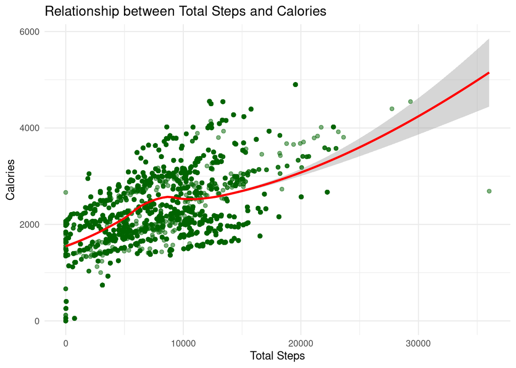

```r
ggplot(data = DailyActivity_Sleepday_merged, aes(x = TotalSteps, y = Calories)) +
  geom_point(color = "dark green", alpha = 0.5) +
  geom_smooth(method = "loess", color = "red")+
  labs(title = "Relationship between Total Steps and Calories",
       x = "Total Steps",
       y = "Calories") +
  theme_minimal()
```

Here we can see that there is a positive corelation between Total Steps taken and Calories burnt. The more the activity, the more calories burnt. However, this only based off of these two variables that we have been working with. There could be other factors at play as well that could alter the results.

I will look into the relationship between Steps and Sedentary time. I will plot a chart using the following code chunk:

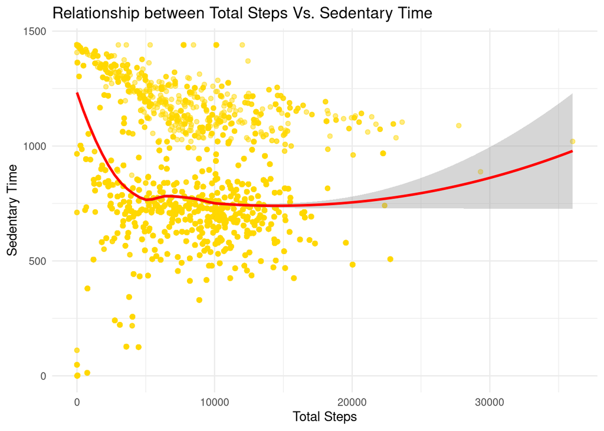

```r
ggplot(data = DailyActivity_Sleepday_merged, aes(x = TotalSteps, y = SedentaryMinutes))+
  geom_point(color = "gold", alpha = 0.5) +
  geom_smooth(method = "loess", color = "red")+
  labs(title = "Relationship between Total Steps Vs. Sedentary Time",
x = "Total Steps",
y= "Sedentary Time")+
  theme_minimal()
```

As we can see from the above plot, there is a negative corelation between Total Steps taken and Sedentary time. Meaning, the more awake and active you are, the less sedentary, or inactive, time you spend. This data shows us that Bellabeat needs to put their marketing efforts on customers showing data with high Sedentary times.

Next, I will be analyzing the Total Steps versus the Total Distance data. I would assume that these two variables would have a positive corealtion, however, there could be other factors at play, such as, not everyone takes the same amount of stride in their steps. Some people take longer, some shorter. Some people also walk faster than others.

I will use the following code chunk:

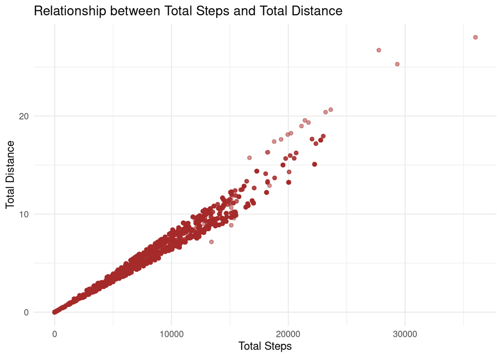

```r
ggplot(data = DailyActivity_Sleepday_merged, aes(x = TotalSteps, y = TotalDistance)) +
  geom_point(color = "brown", alpha = 0.5) +  # Scatter plot with blue points
  labs(title = "Relationship between Total Steps and Total Distance",
       x = "Total Steps",
       y = "Total Distance") +
  theme_minimal()
```

In my next step, I will be analyzing the relationship between Total Minutes Asleep versus Total Time in bed. Recent studies show that people are unable to fall asleep due to varying reasons, once in bed, and end up spending too much time on their phones or doing other things. This can negatively effect their sleep paterns and quality of life.

Here is the code chunk I used to plot this information:

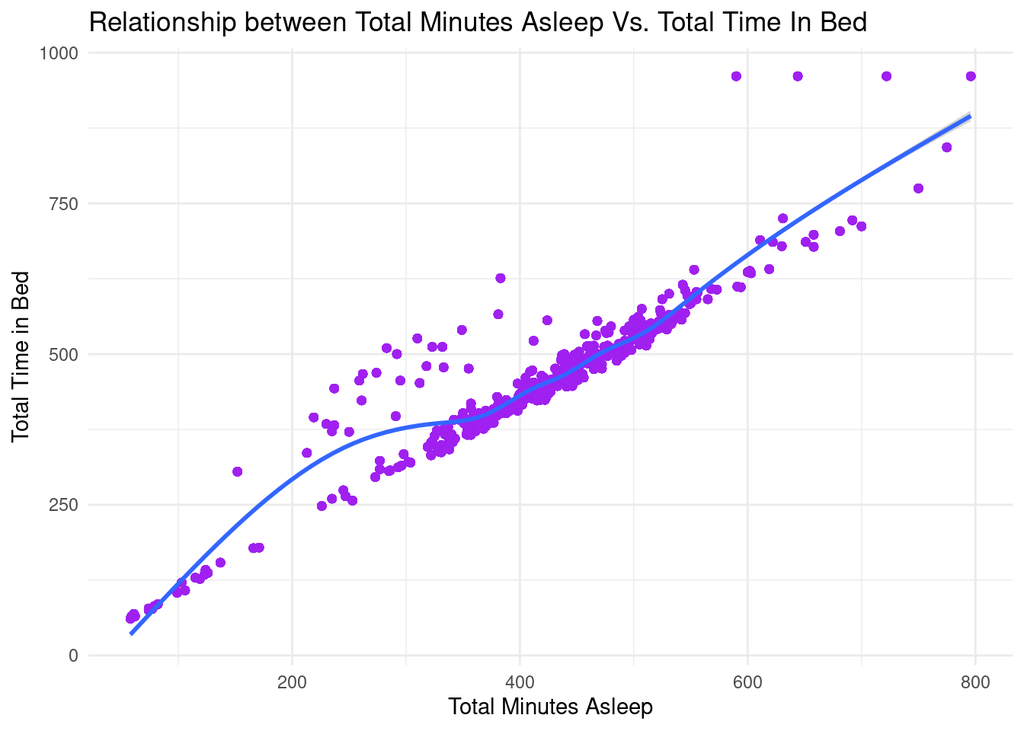

```r
ggplot(data = DailyActivity_Sleepday_merged, aes(x = TotalMinutesAsleep, y = TotalTimeInBed))+
  geom_point(color = "purple", alpha = 0.5)+
  geom_smooth()+
  labs(title = "Relationship between Total Minutes Asleep Vs. Total Time In Bed",
       x = "Total Minutes Asleep",
       y = "Total Time in Bed")+
  theme_minimal()
```

From the above plot, we can see a clear positive corelation between Time in Bed Vs. Total Minutes asleep, for the most part. I would highly recommend Bellabeat to focus on the outliers here. As we can see, there are a number of participants who are spending a lot of time in bed but not enough slepping. Example, on the higher end of the spectrum, there are individuals who are spending around a 1000 minutes in bed but only sleeping between 600-800 minutes.

An effective marketing campaign would be one to target these individuals who are considered outliers so help encourage them to track their sleeping patterns and habits. This could be done by using one of Bellabeat’s tech products to maybe set alarms to alert individuals that it is time to go to sleep.

CDC recommends that adults between the ages of 18-64 should be sleeping between 7-9 hours a night for optimum health and function.

This code converts the values in the VeryActiveMinutes column from minutes to hours. By dividing each minute value by 60, you get the equivalent number of hours.

Dive by 60 to get the correct calculation:

```r
DailyIntensities$VeryActiveMinutes <- (DailyIntensities$VeryActiveMinutes)/60
```

Creating a new Data Frame called “Combined Data”

```r
Combined_data <- merge(Weight, DailyIntensities, by="Id", all = TRUE)
```

```r
Combined_data$time <- format(Combined_data$Date, format = "%H:%M:%S")
```

```r
Time_VeryActiveMinutes_merged <- Combined_data %>%
  select(time, VeryActiveMinutes)
```

Let’s plot the graph:

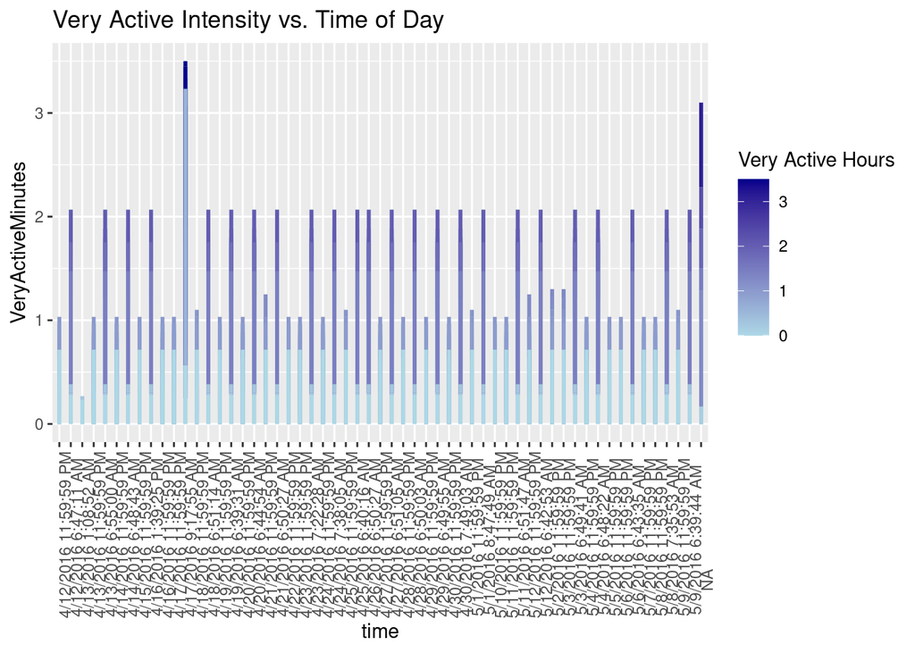

```r
ggplot(data = Time_VeryActiveMinutes_merged, aes(x = time, y = VeryActiveMinutes, color = VeryActiveMinutes)) +
  geom_line(size = 1) +  # Adjust line size as needed
  scale_color_gradient(low = "lightblue", high = "darkblue") +  # Gradient color scale
  theme(axis.text.x = element_text(angle = 90)) +  # Rotate x-axis labels
  labs(title = "Very Active Intensity vs. Time of Day", color = "Very Active Hours")
```

Now I am going to compare the data on an average steps by user basis using their unique IDs. Here is the code:

```r
average_daily_steps_user <- DailyActivity %>%
  group_by(Id) %>%
  summarise(AverageSteps = mean(TotalSteps, na.rm = TRUE))
```

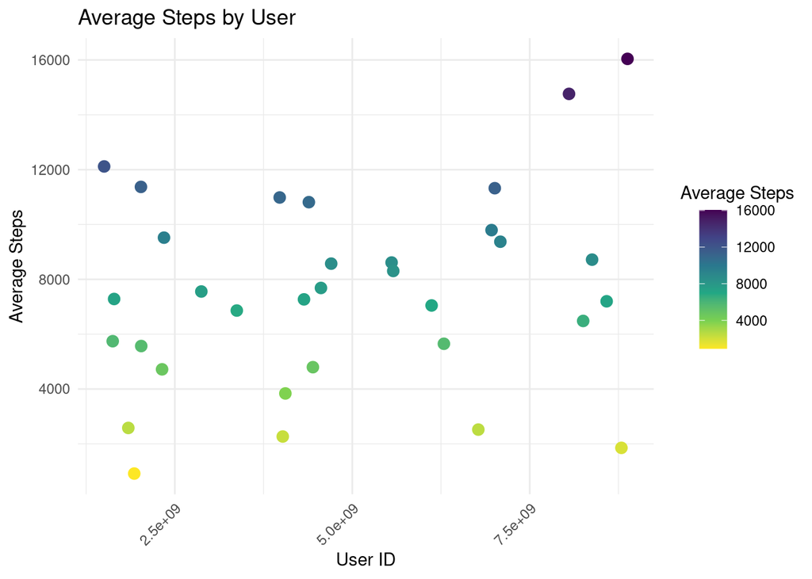

```r
ggplot(average_daily_steps_user, aes(x = Id, y = AverageSteps)) +
  geom_point(aes(color = AverageSteps), size = 3) +  # Use AverageSteps for gradient color
  scale_color_viridis_c(option = "D", direction = -1) +  # Continuous color scale
  labs(title = "Average Steps by User",
       x = "User ID",
       y = "Average Steps",
       color = "Average Steps") +
  theme_minimal() +
  theme(axis.text.x = element_text(angle = 45, hjust = 1)) +
  guides(color = guide_colorbar(title = "Average Steps",
                                title.position = "top",
                                title.hjust = 0.5,
                                bar.width = 1.5,
                                bar.height = 10))
```

5. SHARE

In this phase of my analysis, I was able to share this study with my wife and and some family members to get their unbiased opinions. Through those, I was able to get more keypoints to research further and alter my study to be more insightful and helpful.

6. ACT

In this final phase of my analysis and research, I will be sharing my conclusions and recommendations for Bellabeat.

Through the analysis process, I feel like the target audience for Bellabeat should be the population which is not very active in terms of overall activity. This includes the Sedentary population, folks who lay in bed longer than they sleep, as well as people who sit on their desks all day and have full time jobs.

According to the Total Steps Vs. Sedentary Time study, there is a negative correlation here. Meaning, when people are being sedentary, they are not being active, and in turn there is not much physical movement. This leads to health issues. A good marketing strategy here would be for Bellabeat’s products to send alerts or messages for this population to get up and active.

Furthermore, as we learned from the Total Minutes Asleep Vs. Total Time in Bed study is that these 2 also have a positive correlation. However, there are quite a number of users who are spending a lot more time in bed versus sleeping. This can negatively effect sleeping patterns, sleep health, and health overall. Bellabeat should target this audience and have their products help educate them by sending messages on healthy living. Along with that, users should also get notifications to go to sleep with the ability to track their sleeping patterns in the app in the morning.

Finally, Bellabeat can also focus their marketing campaign on the population who wants to lose weight and get in shape. Based off the Total Steps Vs. Calories and Total Calories Burnt Vs. Total Distance, there is a positive correlation between each one of these variable. Ultimately, the more active you are, the more calories you will burn and lose weight. Bellabeat’s products can send reminders and incentives for users to get motivated and get active. Bellabeat could also include promotions, vouchers, and coupons on their products if some health and usage requirements are met by users to help motivate them. Bellabeat can also make available offers within their app (or ad-ons) where users can get a customized health and food plan, including calorie tracking.